# reading_data_from_web

Johnstone Tcheou

2024-10-08

## Example data

- load tidyverse, p8105.datasets, and nyc_airbnb dataset
- there is a unique Airbnb identifier, review scores with stars out of 5 multiplied by 2 (as they didn’t want half stars)
- this is the data we have so what kind of questions do we want to ask?
- where are the max and min Airbnb prices?
  - what are avg prices?
  - what factors affect prices? how much does location, etc matter?
- where are prices going up and down over time?
- does room type affect availability (are private rooms more or less frequently available than whole apartments)?
- what are locations of units
  - what areas are popular?
  - how much does popularity = number of units? avg price?
- are there repeat hosts?
  - if so, what does that mean? (and what does that mean can mean a variety of things)

```r
data(nyc_airbnb)

summary(pull(nyc_airbnb, price))
```

```
##    Min. 1st Qu.  Median    Mean 3rd Qu.    Max.
##    10.0    70.0   100.0   145.3   170.0 10000.0
```

```r
nyc_airbnb |>
  summarize (max_price = max (price))
```

```
## # A tibble: 1 × 1
##   max_price
##       <dbl>
## 1     10000
```

```r
nyc_airbnb |>
  summarize (min_price = min (price))
```

```
## # A tibble: 1 × 1
##   min_price
##       <dbl>
## 1        10
```

```r
nyc_airbnb |>
  summarize (ave_price = mean (price))
```

```
## # A tibble: 1 × 1
##   ave_price
##       <dbl>
## 1      145.
```

```r
nyc_airbnb |>
  group_by(neighbourhood_group, neighbourhood) |>
  summarize(max(n()))
```

```
## # A tibble: 217 × 3
## # Groups:   neighbourhood_group [5]
##    neighbourhood_group neighbourhood     `max(n())`
##    <chr>               <chr>                  <int>
##  1 Bronx               Allerton                  23
##  2 Bronx               Baychester                 6
##  3 Bronx               Belmont                    8
##  4 Bronx               Bronxdale                 12
##  5 Bronx               Castle Hill                1
##  6 Bronx               City Island                7
##  7 Bronx               Claremont Village          9
##  8 Bronx               Clason Point              21
##  9 Bronx               Co-op City                 5
## 10 Bronx               Concourse                 37
## # ℹ 207 more rows
```

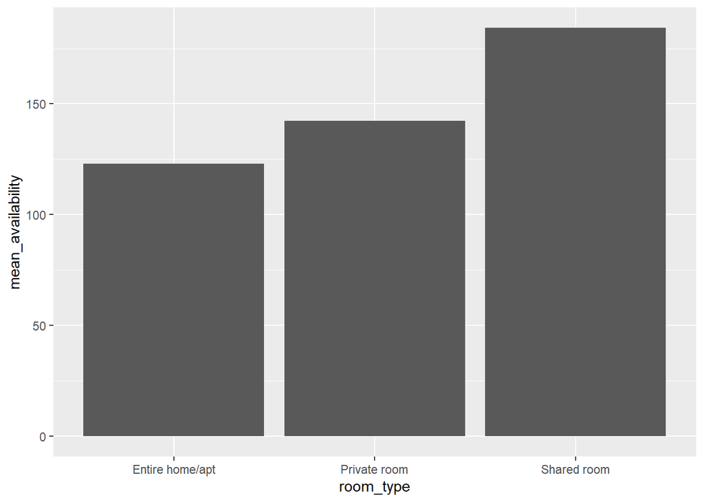

```r
nyc_airbnb |>
  group_by(room_type) |>
  summarize(mean_availability = mean(availability_365)) |>
  ggplot(aes(x = room_type, y = mean_availability)) +
  geom_bar(stat = "identity")
```

```r
nyc_airbnb |>
  group_by(neighbourhood_group) |>
  summarize(
    n = n(),
    avg_price = mean(price),
    avg_reviews_month = mean(reviews_per_month, na.rm = TRUE),
    avg_num_reviews = mean(number_of_reviews, na.rm = TRUE))
```

```
## # A tibble: 5 × 5
##   neighbourhood_group     n avg_price avg_reviews_month avg_num_reviews
##   <chr>               <int>     <dbl>             <dbl>           <dbl>
## 1 Bronx                 649      82.8              1.53            15.2
## 2 Brooklyn            16810     120.               1.21            15.7
## 3 Manhattan           19212     180.               1.32            16.9
## 4 Queens               3821      94.7              1.66            17.4
## 5 Staten Island         261     128.               1.64            18.2
```

Max price = 10^{4} Min price = 10 Avg price = 145.2863593

## More stuff

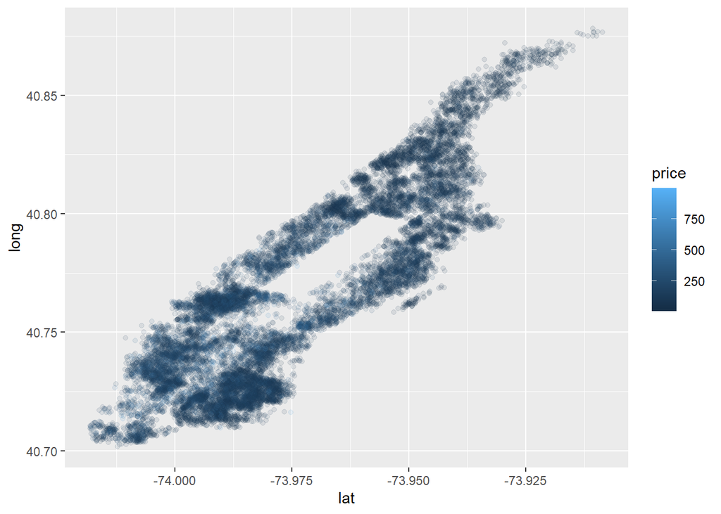

```r
nyc_airbnb |>
  filter(
    neighbourhood_group == "Manhattan",
    price < 1000
  ) |>
  ggplot(aes(x = lat, y = long, color = price)) +
  geom_point(alpha = .1)
```

```r
nyc_airbnb |>
  filter(
    neighbourhood_group == "Manhattan",
    price < 1000,
    room_type == "Entire home/apt"
  ) |>
  group_by(neighbourhood) |>
  summarize(mean_price = mean(price)) |>
  arrange(mean_price)
```

```
## # A tibble: 32 × 2
##    neighbourhood       mean_price
##    <chr>                    <dbl>
##  1 Marble Hill               101.
##  2 Inwood                    119.
##  3 Roosevelt Island          131.
##  4 Washington Heights        133.
##  5 Morningside Heights       151.
##  6 East Harlem               163.
##  7 Harlem                    164.
##  8 Two Bridges               174.
##  9 Upper East Side           193.
## 10 Lower East Side           205.
## # ℹ 22 more rows
```

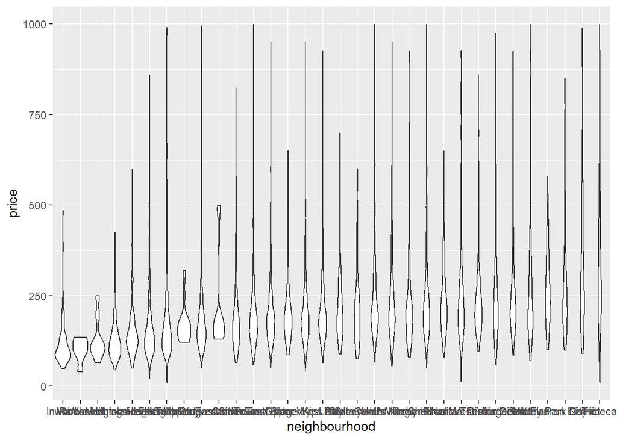

```r
nyc_airbnb |>
  filter(
    neighbourhood_group == "Manhattan",
    price < 1000,
    room_type == "Entire home/apt"
  ) |>
  mutate(neighbourhood = fct_reorder(neighbourhood, price)) |> # puts neighborhoods in order by avg price
  ggplot(aes(x = neighbourhood, y = price)) +
  geom_violin() +
  theme()
```

## how to make better maps

`leaflet` package is great - look at intro to it at https://teachdatascience.com/leaflet/ behaves similarly to ggplot - define aesthetics with lat and long variables from data, initialize leaflet, and add on tiles, then markers, and define further aesthetics like color, radius, etc `leaflet()` initializes leaflet, and `addTiles()` is what adds your data to a map Adding interactive graph to a static document like GitHub document doesn’t work so well - ideal for .HTML instead

```r
nyc_airbnb |>
  filter(
    neighbourhood_group == "Manhattan",
    price < 1000
  ) |>
  leaflet() |>
  addTiles()
```

[interactive chart not shown]

```r
#  addMarkers(~lat, ~long) - running this will crash RStudio as there are way too many observations;

pd <- colorNumeric(
  palette = "viridis",
  domain = nyc_airbnb$review_scores_location
)


nyc_airbnb |>
  filter(
    neighbourhood_group == "Manhattan",
    price < 1000
  ) |>
  leaflet() |>
  addProviderTiles(providers$CartoDB.Positron) |>
  addCircleMarkers(
    ~lat, ~long,
    color = ~ pd(review_scores_location), radius = 2
  )
```

[interactive chart not shown]

## Scraping web content

Webpages are combined HTML (content) and CSS (styling) to make what we see on the webpage Retrieving HTML for a page with desired data retrieves that data, but also a bunch of other stuff Therefore, can be difficult to extract what you want from HTML

## HTML and CSS

CSS controls appearance, so CSS identifiers are scattered throughout HTML code HTML elements you want usually have **unique identifiers** Getting what you want from HTML is usually a question about using an appropriate CSS selector Selector Gadget is most common tool you care about for right CSS selector Go to page you care about launch selector gadget Click on things you want Unclick things you do not want Keep going until only what you want is highlighted Copy the CSS selector

## Scraping data

Use rvest to do webscraping Workflow - download HTML with read-html - Extract elements with html_elements() and CSS selector - extract content from elements using html_text(), html_table(), etc

## API

API - application programming interfaces give a way to communicate with software Web APIs give way to request specific data from server However, APIs are not uniform, e.g. Star Wars API is different from NYC open data API, rnoaa package data comes from API i.e. **what is returned from one API is diff from another API**

## Getting data into R

Web APIs usually accessible via HTML

## API data format

Some APIs have a button where you can easily download the .csv, but not all There are reasons to not do this, as **data changes** so downloading a CSV is a previous snapshot that can be updated, and downloading a new CSV and putting it into R are additional steps, when you can just connect to the API More general instances, you’ll get files in JSON format JavaScript Object

## Web data

Web data is messy, will often take a lot of time to figure it out, i.e. how to get what you want and how to tidy it once you have it

# Code

Note - installation for Selector Gadget is just bookmarking the Selector Gadget JS link - it is something you will need bookmarked

## Extracting tables

We are working w 2013-2014 Ntl Survey on Drug use and Health data, which is kind of messy Structure has since been updated in later years but is still similar Some govt agencies have switched to APIs, some have not, so working with tables is the only way you will be able to use it

First, need to define URL to be read later then read_html() on the URL you just saved, which is basically what your web browser does knowing that data are often in table, html_table() pulls CSS tags on our behalf So html_table() returns a table **indexed 1-15** - all 15 tables on the webpage Now, we need to keep the first element

The output is in a list, which is a format of basically a general collection of objects in R (of varying lengths) Since we just need to keep the first element, we will remove the rest of the tables in the list slice() function lets you select rows by number, so we will subtract 1st row

```r
library(rvest)
library(httr)

url <- "http://samhda.s3-us-gov-west-1.amazonaws.com/s3fs-public/field-uploads/2k15StateFiles/NSDUHsaeShortTermCHG2015.htm"

drug_use_html <- read_html(url)

drug_use_html |>
  html_table()
```

```
## [[1]]
## # A tibble: 57 × 16
##    State     `12+(2013-2014)` `12+(2014-2015)` `12+(P Value)` `12-17(2013-2014)`
##    <chr>     <chr>            <chr>            <chr>          <chr>
##  1 "NOTE: S… "NOTE: State an… "NOTE: State an… "NOTE: State … "NOTE: State and …
##  2 "Total U… "12.90a"         "13.36"          "0.002"        "13.28b"
##  3 "Northea… "13.88a"         "14.66"          "0.005"        "13.98"
##  4 "Midwest" "12.40b"         "12.76"          "0.082"        "12.45"
##  5 "South"   "11.24a"         "11.64"          "0.029"        "12.02"
##  6 "West"    "15.27"          "15.62"          "0.262"        "15.53a"
##  7 "Alabama" "9.98"           "9.60"           "0.426"        "9.90"
##  8 "Alaska"  "19.60a"         "21.92"          "0.010"        "17.30"
##  9 "Arizona" "13.69"          "13.12"          "0.364"        "15.12"
## 10 "Arkansa… "11.37"          "11.59"          "0.678"        "12.79"
## # ℹ 47 more rows
## # ℹ 11 more variables: `12-17(2014-2015)` <chr>, `12-17(P Value)` <chr>,
## #   `18-25(2013-2014)` <chr>, `18-25(2014-2015)` <chr>, `18-25(P Value)` <chr>,
## #   `26+(2013-2014)` <chr>, `26+(2014-2015)` <chr>, `26+(P Value)` <chr>,
## #   `18+(2013-2014)` <chr>, `18+(2014-2015)` <chr>, `18+(P Value)` <chr>
##
## [[2]]
## # A tibble: 57 × 16
##    State     `12+(2013-2014)` `12+(2014-2015)` `12+(P Value)` `12-17(2013-2014)`
##    <chr>     <chr>            <chr>            <chr>          <chr>
##  1 "NOTE: S… "NOTE: State an… "NOTE: State an… "NOTE: State … "NOTE: State and …
##  2 "Total U… "7.96a"          "8.34"           "0.001"        "7.22"
##  3 "Northea… "8.58a"          "9.28"           "0.001"        "7.68"
##  4 "Midwest" "7.50a"          "7.92"           "0.009"        "6.64"
##  5 "South"   "6.74a"          "7.02"           "0.044"        "6.31"
##  6 "West"    "9.84"           "10.08"          "0.324"        "8.85"
##  7 "Alabama" "5.57"           "5.35"           "0.510"        "4.98"
##  8 "Alaska"  "11.85a"         "14.38"          "0.002"        "9.19"
##  9 "Arizona" "8.80"           "8.51"           "0.570"        "8.30"
## 10 "Arkansa… "6.70"           "7.17"           "0.240"        "6.22"
## # ℹ 47 more rows
## # ℹ 11 more variables: `12-17(2014-2015)` <chr>, `12-17(P Value)` <chr>,
## #   `18-25(2013-2014)` <chr>, `18-25(2014-2015)` <chr>, `18-25(P Value)` <chr>,
## #   `26+(2013-2014)` <chr>, `26+(2014-2015)` <chr>, `26+(P Value)` <chr>,
## #   `18+(2013-2014)` <chr>, `18+(2014-2015)` <chr>, `18+(P Value)` <chr>
##
```

[output cut: 236 more lines]

```
##    <chr>     <chr>            <chr>            <chr>          <chr>
##  1 "NOTE: S… "NOTE: State an… "NOTE: State an… "NOTE: State … "NOTE: State and …
##  2 "Total U… "6.63"           "6.64"           "0.915"        "11.01a"
##  3 "Northea… "6.66"           "6.82"           "0.458"        "10.63a"
##  4 "Midwest" "6.81"           "6.87"           "0.736"        "10.81a"
##  5 "South"   "6.47"           "6.52"           "0.750"        "10.77a"
##  6 "West"    "6.67"           "6.47"           "0.353"        "11.82a"
##  7 "Alabama" "6.85"           "6.81"           "0.948"        "10.74"
##  8 "Alaska"  "6.57"           "6.73"           "0.770"        "9.92a"
##  9 "Arizona" "7.32"           "6.77"           "0.362"        "13.23"
## 10 "Arkansa… "7.31"           "7.78"           "0.446"        "11.95"
## # ℹ 47 more rows
## # ℹ 8 more variables: `12-17(2014-2015)` <chr>, `12-17(P Value)` <chr>,
## #   `18-25(2013-2014)` <chr>, `18-25(2014-2015)` <chr>, `18-25(P Value)` <chr>,
## #   `26+(2013-2014)` <chr>, `26+(2014-2015)` <chr>, `26+(P Value)` <chr>
```

```r
marj_use_df <-
  drug_use_html |>
  html_table() |>
  first() |>
  slice(-1)
```

## learning assesssment

HTML table is still returning list, but only has 1 object in it We can still take first element of list However, titles of the variables have been read as first row, leaving columns named as X1-X4 accordingly Multiple ways to do this, one of which is specifying that first row are headers with header = TRUE in html_table()

```r
col_url <- "https://www.bestplaces.net/cost_of_living/city/new_york/new_york"

col_html <- read_html(col_url)

col_html |>
  html_table(header = TRUE) |>
  first()
```

```
## # A tibble: 8 × 4
##   Categories       `New York` `New York` `United States`
##   <chr>            <chr>      <chr>      <chr>
## 1 Overall          172.5      121.5      100.0
## 2 Grocery          116.6      103.8      100
## 3 Health           127.6      120.7      100.0
## 4 Housing          224.3      127.9      100.0
## 5 Median Home Cost $677,200   $413,600   $338,100
## 6 Utilities        150.5      115.9      100
## 7 Transportation   181.1      140.7      100.0
## 8 Miscellaneous    136.4      121.8      100.0
```

```r
nyc_cost_df <-
  read_html("https://www.bestplaces.net/cost_of_living/city/new_york/new_york") |>
  html_table(header = TRUE) |>
  first()
```

## CSS selectors

maybe we want data from webpage that isn’t in table format, but we want it in a table How do we get these elements into a table in R? e.g. titles, runtime, year, etc from IMDB we will import the HTML and extract just the elements we want Use the Selector Gadget bookmark, select what you want, which will highlight the element in green, then what you don’t want, which will highlight the element in red This will eventually output the CSS tags for the HTML elements you want at the bottom **MAKE SURE TO USE HTML_ELEMENTS() NOT HTML_ELEMENT() IF YOU WANT MORE THAN JUST THE FIRST INSTANCE OF YOUR ELEMENT**

```r
swm_url <- "https://www.imdb.com/list/ls070150896/"

swm_html <- read_html(swm_url)


swm_score_vec <- swm_html |>
  html_elements(".metacritic-score-box") |>
  html_text()

swm_title_vec <- swm_html |>
  html_elements(".ipc-title-link-wrapper") |>
  html_text()

swm_runtime_vec <- swm_html |>
  html_elements(".dli-title-metadata-item:nth-child(2)") |>
  html_text()

swm_df <-
  tibble(
    title = swm_title_vec,
    runtime = swm_runtime_vec,
    score = swm_score_vec
  )

books_url <- "https://books.toscrape.com/"

books_html <- read_html(books_url)

books_html |>
  html_elements(".product_pod a") |>
  html_text()
```

```
##  [1] ""
##  [2] "A Light in the ..."
##  [3] ""
##  [4] "Tipping the Velvet"
##  [5] ""
##  [6] "Soumission"
##  [7] ""
##  [8] "Sharp Objects"
##  [9] ""
## [10] "Sapiens: A Brief History ..."
## [11] ""
## [12] "The Requiem Red"
## [13] ""
## [14] "The Dirty Little Secrets ..."
## [15] ""
```

[output cut: 25 more lines]

```r
books_html |>
  html_elements(".price_color") |>
  html_text()
```

```
##  [1] "£51.77" "£53.74" "£50.10" "£47.82" "£54.23" "£22.65" "£33.34" "£17.93"
##  [9] "£22.60" "£52.15" "£13.99" "£20.66" "£17.46" "£52.29" "£35.02" "£57.25"
## [17] "£23.88" "£37.59" "£51.33" "£45.17"
```

## Some asides

Be careful to not accidentally cause a DDoS when reading from the web This is also why Amazon put their reviews behind an API after Jeff had him do this exercise with Amazon reviews last year Another aside is sometimes these elements from the CSS selector can be unstable When you get read more or show more on a webpage, it shouldn’t affect the webscraping - only exception is if you click read more and it refreshes, but everything else is in the HTML If your elements are all on separate pages, like first page is only items 1-40, second page is 40-80, etc, then you would have to scrape from each page separately

## API

NYC water consumption is available as an API Copy and paste this link for the API API knows we want semi leiglbe data and will try to give us semi legible data GET() is a common API call, so we will use this function and supply it the API link

```r
(nyc_water <-
  GET("https://data.cityofnewyork.us/resource/ia2d-e54m.csv")) |>
  content("parsed")
```

```
## # A tibble: 45 × 4
##     year new_york_city_population nyc_consumption_milli…¹ per_capita_gallons_p…²
##    <dbl>                    <dbl>                   <dbl>                  <dbl>
##  1  1979                  7102100                    1512                    213
##  2  1980                  7071639                    1506                    213
##  3  1981                  7089241                    1309                    185
##  4  1982                  7109105                    1382                    194
##  5  1983                  7181224                    1424                    198
##  6  1984                  7234514                    1465                    203
##  7  1985                  7274054                    1326                    182
##  8  1986                  7319246                    1351                    185
##  9  1987                  7342476                    1447                    197
## 10  1988                  7353719                    1484                    202
## # ℹ 35 more rows
## # ℹ abbreviated names: ¹nyc_consumption_million_gallons_per_day,
## #   ²per_capita_gallons_per_person_per_day
```

can also import as JSON

```r
nyc_water =
  GET("https://data.cityofnewyork.us/resource/ia2d-e54m.json") |>
  content("text") |>
  jsonlite::fromJSON() |>
  as_tibble()
```

## Pokemon API

Once loading content(), this format is NOT in CSV, whole bunch of messy data In general, there are datasets more complicated than what CSVs look like, which is what APIs often return and this is one of those instances Getting data

```r
pokemon <-
  GET("http://pokeapi.co/api/v2/pokemon/1") |>
  content()

pokemon$abilities
```

```
## [[1]]
## [[1]]$ability
## [[1]]$ability$name
## [1] "overgrow"
##
## [[1]]$ability$url
## [1] "https://pokeapi.co/api/v2/ability/65/"
##
##
## [[1]]$is_hidden
## [1] FALSE
##
## [[1]]$slot
## [1] 1
##
##
## [[2]]
## [[2]]$ability
## [[2]]$ability$name
## [1] "chlorophyll"
##
## [[2]]$ability$url
## [1] "https://pokeapi.co/api/v2/ability/34/"
##
##
## [[2]]$is_hidden
## [1] TRUE
##
## [[2]]$slot
## [1] 3
```